# Cluster_Analysis

AhmedLubis

2026-05-16

Preparation

```r
#reading_data
customer_data <- read.csv("D:/Kuliah/STA 2581 - Sains Data/STA 2581.Project/wholesale_customers_data.csv")

head(customer_data)
```

```
##   Channel Region Fresh Milk Grocery Frozen Detergents_Paper Delicassen
## 1       2      3 12669 9656    7561    214             2674       1338
## 2       2      3  7057 9810    9568   1762             3293       1776
## 3       2      3  6353 8808    7684   2405             3516       7844
## 4       1      3 13265 1196    4221   6404              507       1788
## 5       2      3 22615 5410    7198   3915             1777       5185
## 6       2      3  9413 8259    5126    666             1795       1451
```

```r
#data_structure
str(customer_data)
```

```
## 'data.frame':    440 obs. of  8 variables:
##  $ Channel         : int  2 2 2 1 2 2 2 2 1 2 ...
##  $ Region          : int  3 3 3 3 3 3 3 3 3 3 ...
##  $ Fresh           : int  12669 7057 6353 13265 22615 9413 12126 7579 5963 6006 ...
##  $ Milk            : int  9656 9810 8808 1196 5410 8259 3199 4956 3648 11093 ...
##  $ Grocery         : int  7561 9568 7684 4221 7198 5126 6975 9426 6192 18881 ...
##  $ Frozen          : int  214 1762 2405 6404 3915 666 480 1669 425 1159 ...
##  $ Detergents_Paper: int  2674 3293 3516 507 1777 1795 3140 3321 1716 7425 ...
##  $ Delicassen      : int  1338 1776 7844 1788 5185 1451 545 2566 750 2098 ...
```

```r
summary(customer_data)
```

```
##     Channel          Region          Fresh             Milk
##  Min.   :1.000   Min.   :1.000   Min.   :     3   Min.   :   55
##  1st Qu.:1.000   1st Qu.:2.000   1st Qu.:  3128   1st Qu.: 1533
##  Median :1.000   Median :3.000   Median :  8504   Median : 3627
##  Mean   :1.323   Mean   :2.543   Mean   : 12000   Mean   : 5796
##  3rd Qu.:2.000   3rd Qu.:3.000   3rd Qu.: 16934   3rd Qu.: 7190
##  Max.   :2.000   Max.   :3.000   Max.   :112151   Max.   :73498
##     Grocery          Frozen        Detergents_Paper    Delicassen
##  Min.   :    3   Min.   :   25.0   Min.   :    3.0   Min.   :    3.0
##  1st Qu.: 2153   1st Qu.:  742.2   1st Qu.:  256.8   1st Qu.:  408.2
##  Median : 4756   Median : 1526.0   Median :  816.5   Median :  965.5
##  Mean   : 7951   Mean   : 3071.9   Mean   : 2881.5   Mean   : 1524.9
##  3rd Qu.:10656   3rd Qu.: 3554.2   3rd Qu.: 3922.0   3rd Qu.: 1820.2
##  Max.   :92780   Max.   :60869.0   Max.   :40827.0   Max.   :47943.0
```

```r
#data_preparation
data_cluster <- customer_data[, c(
  "Fresh",
  "Milk",
  "Grocery",
  "Frozen",
  "Detergents_Paper",
  "Delicassen"
)]

head(data_cluster)
```

```
##   Fresh Milk Grocery Frozen Detergents_Paper Delicassen
## 1 12669 9656    7561    214             2674       1338
## 2  7057 9810    9568   1762             3293       1776
## 3  6353 8808    7684   2405             3516       7844
## 4 13265 1196    4221   6404              507       1788
## 5 22615 5410    7198   3915             1777       5185
## 6  9413 8259    5126    666             1795       1451
```

Exploration

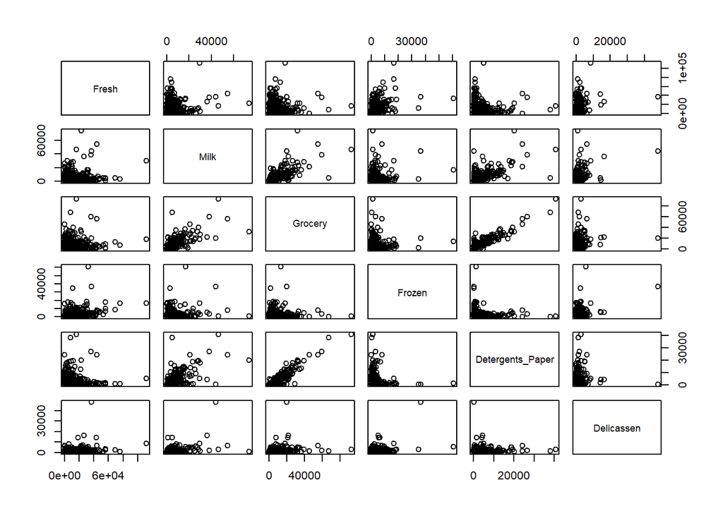

```r
#scatterplot_matrix
pairs(data_cluster)
```

```r
#correlation
cor(data_cluster)
```

```
##                        Fresh      Milk     Grocery      Frozen Detergents_Paper
## Fresh             1.00000000 0.1005098 -0.01185387  0.34588146       -0.1019529
## Milk              0.10050977 1.0000000  0.72833512  0.12399376        0.6618157
## Grocery          -0.01185387 0.7283351  1.00000000 -0.04019274        0.9246407
## Frozen            0.34588146 0.1239938 -0.04019274  1.00000000       -0.1315249
## Detergents_Paper -0.10195294 0.6618157  0.92464069 -0.13152491        1.0000000
## Delicassen        0.24468997 0.4063683  0.20549651  0.39094747        0.0692913
##                  Delicassen
## Fresh             0.2446900
## Milk              0.4063683
## Grocery           0.2054965
## Frozen            0.3909475
## Detergents_Paper  0.0692913
## Delicassen        1.0000000
```

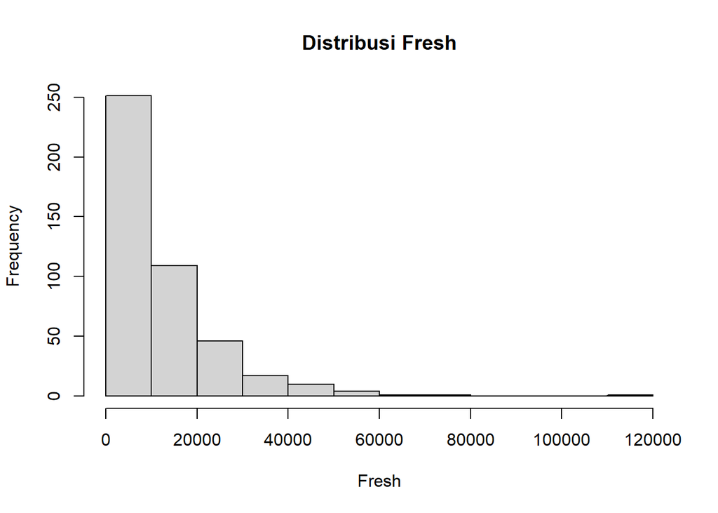

```r
#histogram
hist(data_cluster$Fresh,
     main = "Distribusi Fresh",
     xlab = "Fresh")
```

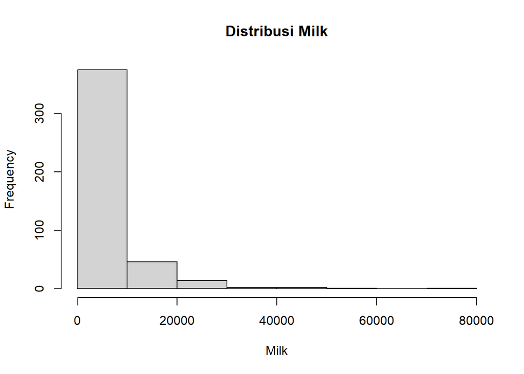

```r
hist(data_cluster$Milk,
     main = "Distribusi Milk",
     xlab = "Milk")
```

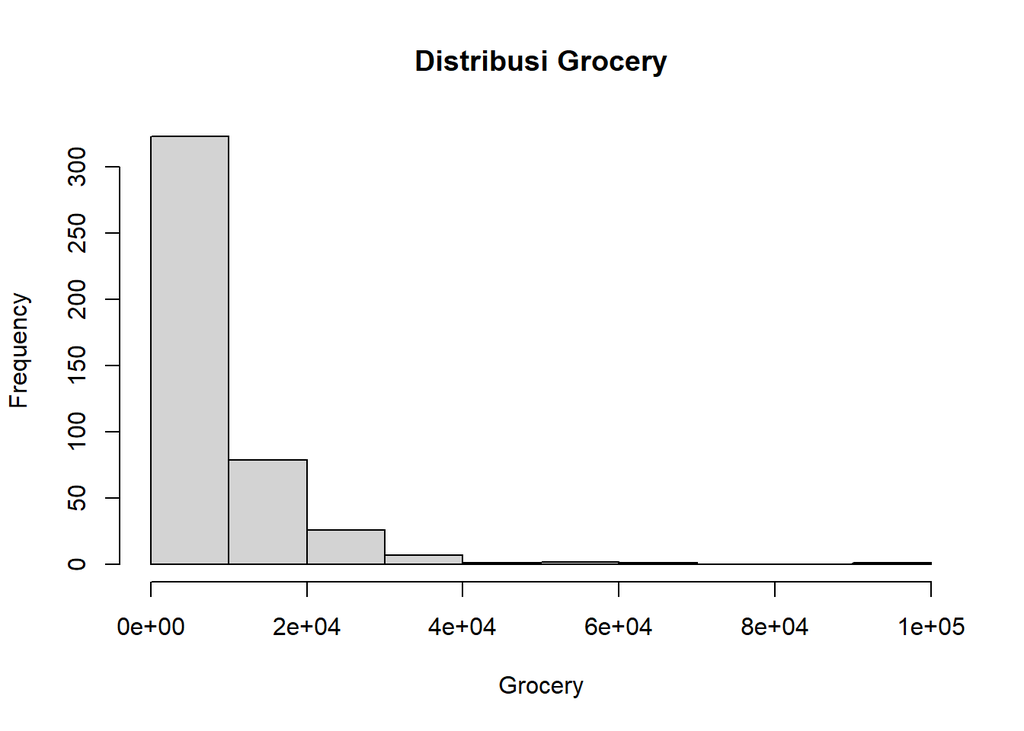

```r
hist(data_cluster$Grocery,
     main = "Distribusi Grocery",
     xlab = "Grocery")
```

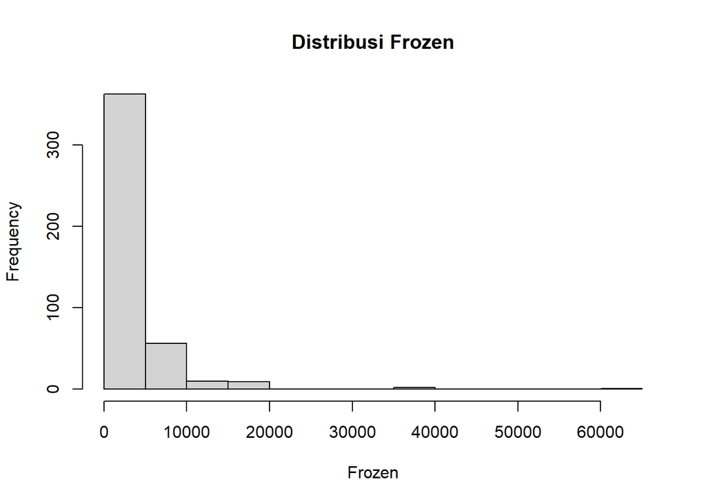

```r
hist(data_cluster$Frozen,
     main = "Distribusi Frozen",
     xlab = "Frozen")
```

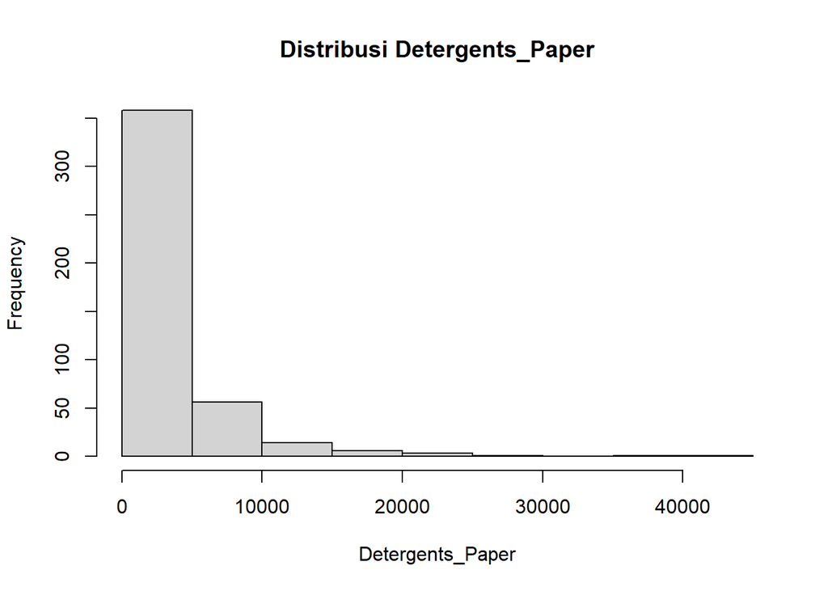

```r
hist(data_cluster$Detergents_Paper,
     main = "Distribusi Detergents_Paper",
     xlab = "Detergents_Paper")
```

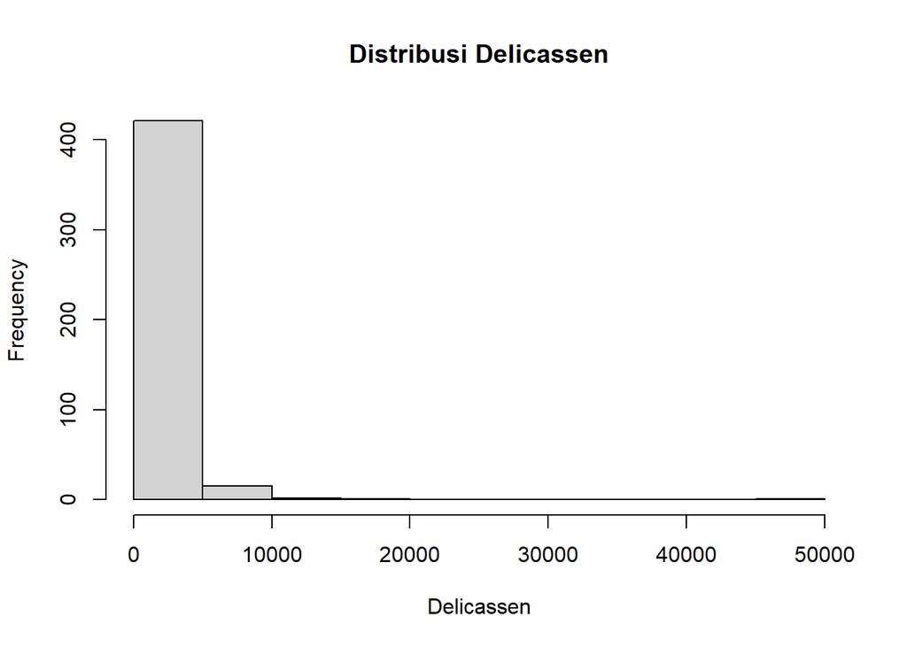

```r
hist(data_cluster$Delicassen,
     main = "Distribusi Delicassen",
     xlab = "Delicassen")
```

It can be seen that every histogram is right-skewed, so we have to transform into log-form

```r
#all_histogram_right-skewed
#copy_og_data
data_log <- data_cluster
#log_transformation-(log_base_e): column 1-6
data_log[, 1:6] <- log(data_cluster[, 1:6] + 1)
```

Exploration data_log

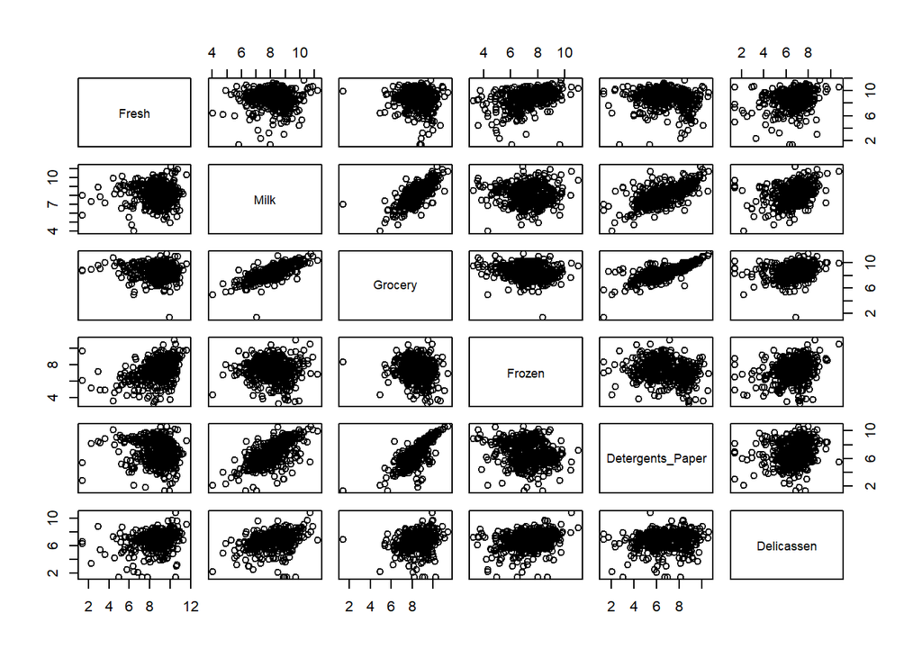

```r
#scatterplot_matrix
pairs(data_log)
```

```r
#correlation
cor(data_log)
```

```
##                        Fresh        Milk    Grocery      Frozen
## Fresh             1.00000000 -0.02109638 -0.1329889  0.38625790
## Milk             -0.02109638  1.00000000  0.7611276 -0.05522851
## Grocery          -0.13298890  0.76112760  1.0000000 -0.16452522
## Frozen            0.38625790 -0.05522851 -0.1645252  1.00000000
## Detergents_Paper -0.15870598  0.67872480  0.7971412 -0.21277086
## Delicassen        0.25644186  0.34231006  0.2399975  0.25631819
##                  Detergents_Paper Delicassen
## Fresh                  -0.1587060  0.2564419
## Milk                    0.6787248  0.3423101
## Grocery                 0.7971412  0.2399975
## Frozen                 -0.2127709  0.2563182
## Detergents_Paper        1.0000000  0.1675729
## Delicassen              0.1675729  1.0000000
```

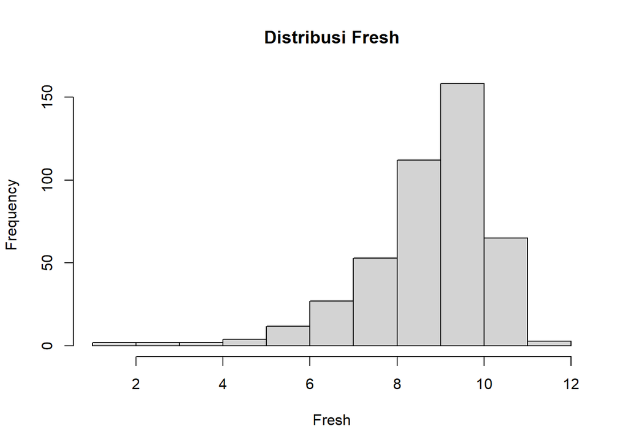

```r
#histogram_log_form
#fresh
hist(data_log$Fresh,
     main = "Distribusi Fresh",
     xlab = "Fresh")
```

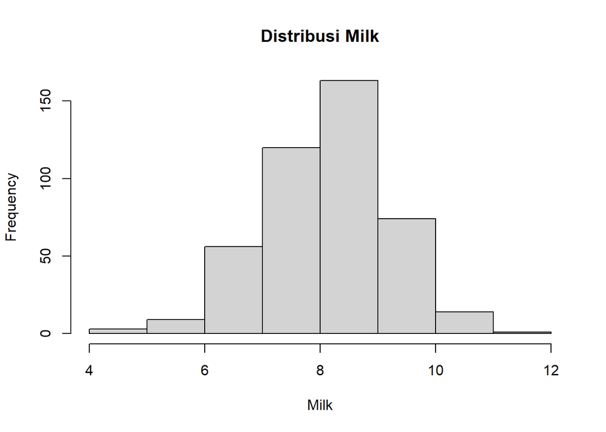

```r
#milk
hist(data_log$Milk,
     main = "Distribusi Milk",
     xlab = "Milk")
```

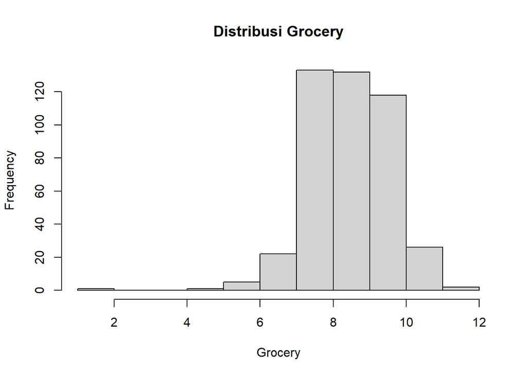

```r
#grocery
hist(data_log$Grocery,
     main = "Distribusi Grocery",
     xlab = "Grocery")
```

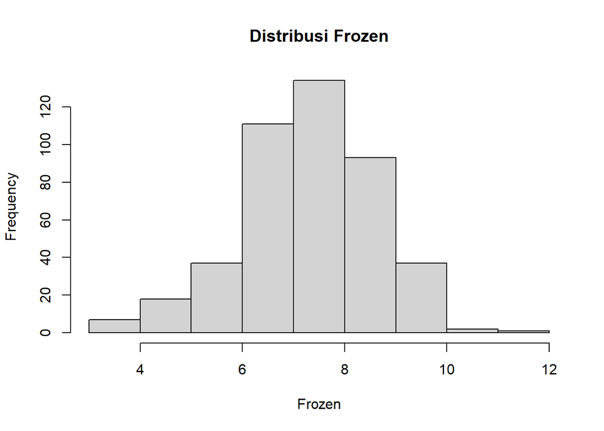

```r
#frozen
hist(data_log$Frozen,
     main = "Distribusi Frozen",
     xlab = "Frozen")
```

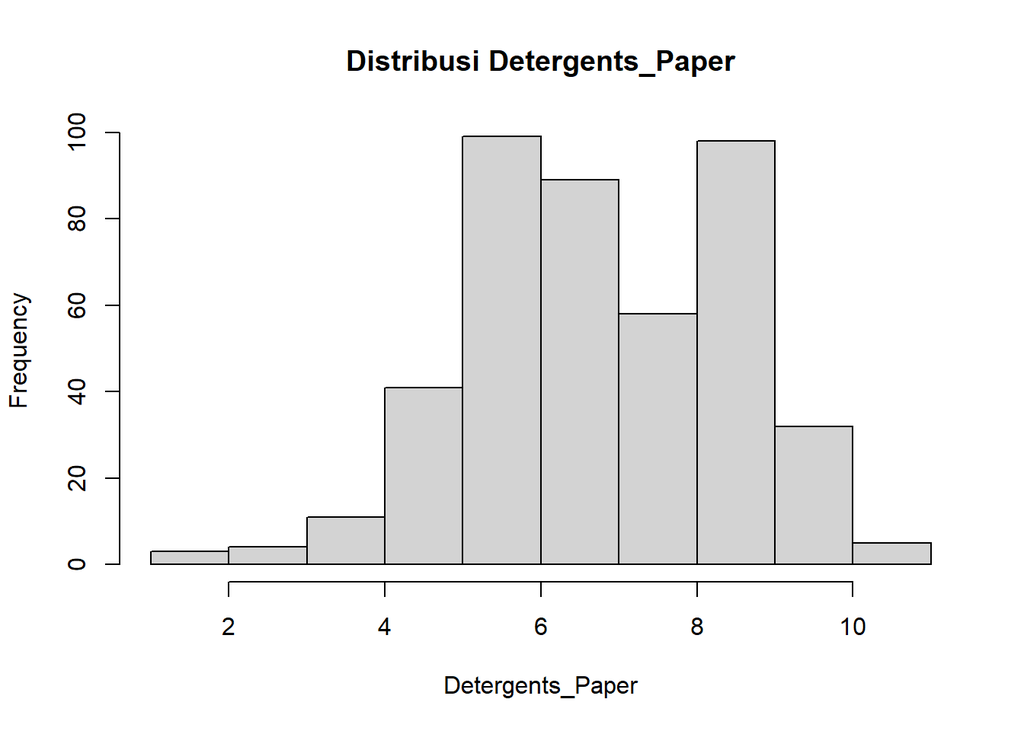

```r
#detergents_paper
hist(data_log$Detergents_Paper,
     main = "Distribusi Detergents_Paper",
     xlab = "Detergents_Paper")
```

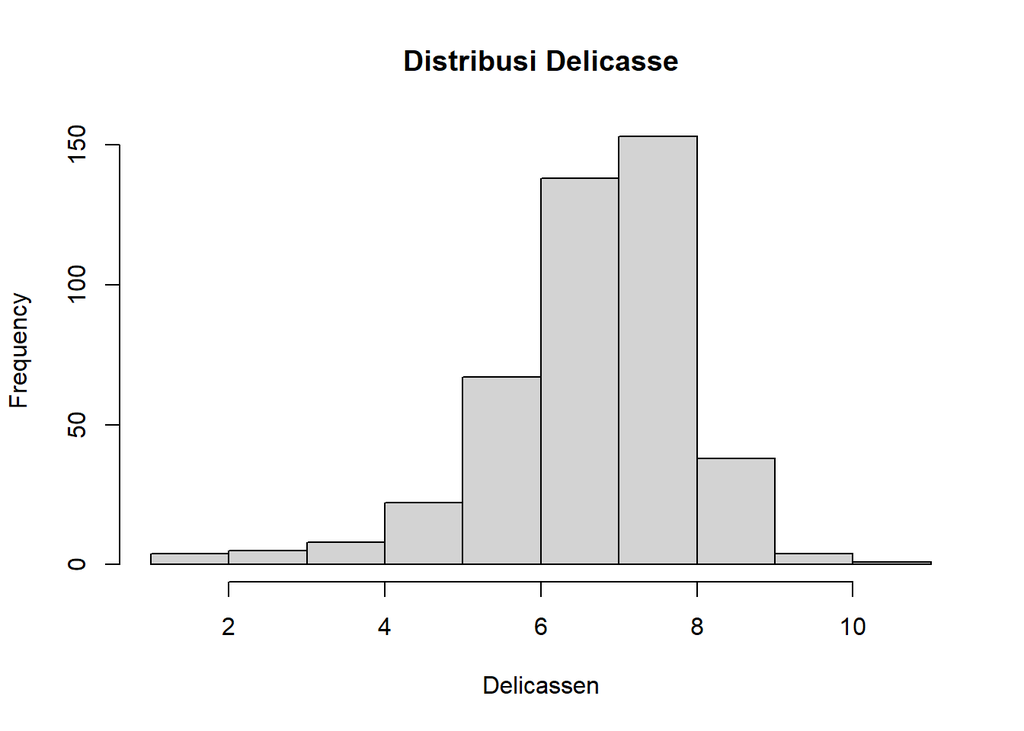

```r
#delicassen
hist(data_log$Delicassen,
     main = "Distribusi Delicasse",
     xlab = "Delicassen")
```

After we have done exploration data, we have to do standardization data

```r
#standardization_data
data_scaled <- scale(data_log)

head(data_scaled)
```

```
##           Fresh       Milk     Grocery     Frozen Detergents_Paper Delicassen
## [1,] 0.48563170  0.9751888  0.43965422 -1.5075338        0.6434109  0.4085010
## [2,] 0.08778870  0.9898294  0.65142933  0.1338998        0.7651721  0.6272121
## [3,] 0.01633769  0.8901377  0.45417004  0.3764707        0.8034903  1.7748131
## [4,] 0.51688887 -0.9568836 -0.08469525  1.1402764       -0.3283378  0.6324134
## [5,] 0.87962962  0.4391620  0.39539643  0.7564611        0.4044781  1.4549317
## [6,] 0.28364930  0.8305900  0.09003047 -0.6243428        0.4103703  0.4711141
```

Next, the step should be done by us is measuring of distance

```r
#distance_measurement
#euclidean_distance
euclidean_distance <- dist(
  data_scaled,
  method = "euclidean"
)

as.matrix(euclidean_distance)[1:5,1:5]
```

```
##          1        2        3        4        5
## 1 0.000000 1.720554 2.381090 3.466144 2.592739
## 2 1.720554 0.000000 1.196349 2.593122 1.482768
## 3 2.381090 1.196349 0.000000 2.668694 1.165347
## 4 3.466144 2.593122 2.668694 0.000000 1.916216
## 5 2.592739 1.482768 1.165347 1.916216 0.000000
```

```r
#manhattan_distance
manhattan_distance <- dist(
  data_scaled,
  method = "manhattan"
)

as.matrix(manhattan_distance)[1:5,1:5]
```

```
##          1        2        3        4        5
## 1 0.000000 2.606165 3.979257 6.331150 4.523641
## 2 2.606165 0.000000 1.796892 5.217025 3.409516
## 3 3.979257 1.796892 0.000000 5.924471 2.471925
## 4 6.331150 5.217025 5.924471 0.000000 4.178028
## 5 4.523641 3.409516 2.471925 4.178028 0.000000
```

```r
#chebyshev_distance
chebyshev_distance <- dist(
  data_scaled,
  method = "maximum"
)

as.matrix(chebyshev_distance)[1:5,1:5]
```

```
##          1         2         3        4         5
## 1 0.000000 1.6414336 1.8840045 2.647810 2.2639949
## 2 1.641434 0.0000000 1.1476010 1.946713 0.8277196
## 3 1.884004 1.1476010 0.0000000 1.847021 0.8632919
## 4 2.647810 1.9467130 1.8470213 0.000000 1.3960457
## 5 2.263995 0.8277196 0.8632919 1.396046 0.0000000
```

```r
#based_on_max_spare
minkowski_distance <- dist(
  data_scaled,
  method = "minkowski",
  p = 3
)

as.matrix(minkowski_distance)[1:5,1:5]
```

```
##          1        2         3        4         5
## 1 0.000000 1.651851 2.1064009 2.994390 2.3500836
## 2 1.651851 0.000000 1.1534834 2.167439 1.1536910
## 3 2.106401 1.153483 0.0000000 2.152236 0.9606147
## 4 2.994390 2.167439 2.1522358 0.000000 1.5721402
## 5 2.350084 1.153691 0.9606147 1.572140 0.0000000
```

After measure of distance, we will do cluster analysis

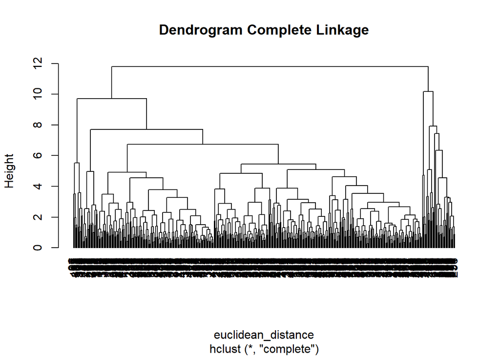

```r
#hierarchial_clustering
#complete_linkage
hc_complete <- hclust(
  euclidean_distance,
  method = "complete"
)

plot(
  hc_complete,
  hang = -1,
  main = "Dendrogram Complete Linkage"
)
```

```r
#creating_cluster
cluster_hc <- cutree(
  hc_complete,
  k = 5
)

cluster_hc
```

```
##   [1] 1 1 1 1 1 1 1 1 1 1 1 1 1 1 1 1 1 1 1 1 1 1 1 1 1 1 1 1 1 1 1 1 1 1 1 1 1
##  [38] 1 1 1 1 1 1 1 1 1 1 1 1 1 1 1 1 1 1 1 1 1 1 1 1 1 1 1 1 2 2 1 1 1 1 1 1 1
##  [75] 1 3 1 1 1 1 1 1 1 1 1 1 1 1 4 1 4 1 1 1 1 2 2 4 4 1 1 1 1 1 1 1 1 1 1 5 1
## [112] 1 1 1 1 1 1 1 1 1 1 1 3 1 1 1 1 1 5 1 1 4 1 1 1 1 1 5 1 1 1 1 5 1 1 1 1 1
## [149] 1 1 1 1 1 1 4 1 1 1 1 1 1 3 1 1 1 1 1 1 1 1 1 2 1 1 1 1 1 1 1 1 1 1 1 1 5
## [186] 1 1 5 1 1 1 4 1 2 1 1 1 1 1 1 1 1 1 5 1 1 1 1 1 1 1 1 1 1 1 1 1 1 2 4 1 1
## [223] 1 1 1 1 1 1 1 1 1 1 1 5 1 1 1 1 4 1 1 1 1 1 1 1 1 3 1 1 1 1 1 1 1 4 1 1 1
## [260] 1 1 4 1 1 1 1 1 1 1 4 4 1 1 1 1 4 1 4 1 1 1 1 1 1 1 4 1 1 1 4 1 1 1 1 1 1
## [297] 1 1 1 4 1 1 1 1 2 1 1 1 1 1 1 1 1 1 1 1 1 1 1 1 1 1 1 1 1 1 1 4 1 1 1 1 1
## [334] 1 1 1 1 1 4 1 1 1 1 1 1 1 1 1 1 1 1 1 4 2 1 4 3 2 1 1 1 1 1 1 1 1 1 1 1 4
## [371] 1 1 1 1 1 1 1 1 1 1 1 1 1 1 1 1 1 1 1 1 1 1 1 1 1 1 1 1 4 1 1 1 1 1 1 1 1
## [408] 1 1 1 1 1 2 1 1 1 1 1 1 1 1 1 1 1 1 1 1 1 1 1 1 1 1 1 1 1 1 1 1 5
```

```r
#adding_cluster_to_data
customer_data$cluster_hc <- cluster_hc

head(customer_data)
```

```
##   Channel Region Fresh Milk Grocery Frozen Detergents_Paper Delicassen
## 1       2      3 12669 9656    7561    214             2674       1338
## 2       2      3  7057 9810    9568   1762             3293       1776
## 3       2      3  6353 8808    7684   2405             3516       7844
## 4       1      3 13265 1196    4221   6404              507       1788
## 5       2      3 22615 5410    7198   3915             1777       5185
## 6       2      3  9413 8259    5126    666             1795       1451
##   cluster_hc
## 1          1
## 2          1
## 3          1
## 4          1
## 5          1
## 6          1
```

```r
#cluster_visualization
library(factoextra)
```

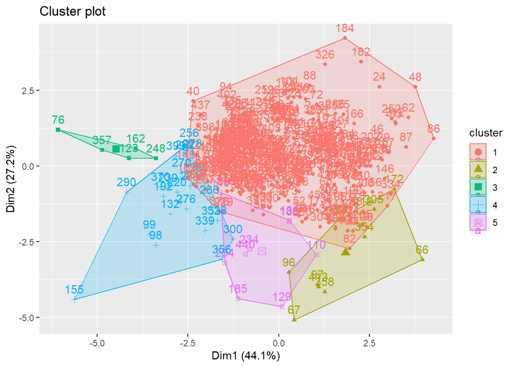

```r
fviz_cluster(
  list(
    data = data_scaled,
    cluster = cluster_hc
  )
)
```

```r
library(dplyr)
customer_data%>%
  group_by(cluster_hc) %>%
  summarise(
    Mean_fresh = mean(Fresh),
    Mean_milk = mean(Milk),
    Mean_grocery = mean(Grocery),
    Mean_frozen = mean(Frozen),
    Mean_detergents_paper = mean(Detergents_Paper),
    Mean_delicassen = mean(Delicassen)
  )
```

```
## # A tibble: 5 × 7
##   cluster_hc Mean_fresh Mean_milk Mean_grocery Mean_frozen Mean_detergents_paper
##        <int>      <dbl>     <dbl>        <dbl>       <dbl>                 <dbl>
## 1          1    12607.      6119.        8148.       3172.                3005.
## 2          2       84.5     7589.       18507.        434.                7379.
## 3          3    16260.       472.         248.       2545.                  16.8
## 4          4     9153.       619.        1505.       3400                  137.
## 5          5     5419.      6344.        7991.       1365                  919.
## # ℹ 1 more variable: Mean_delicassen <dbl>
```

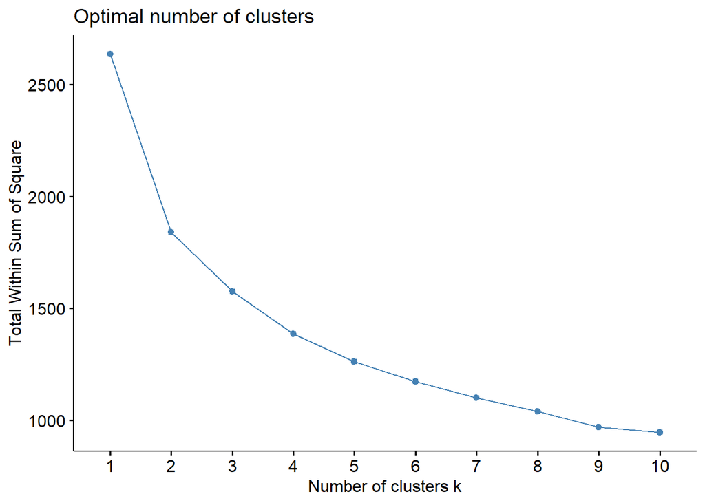

```r
#determine_optimal_number_of_cluster
#elbow_method
fviz_nbclust(
  data_scaled,
  kmeans,
  method = "wss"
)
```

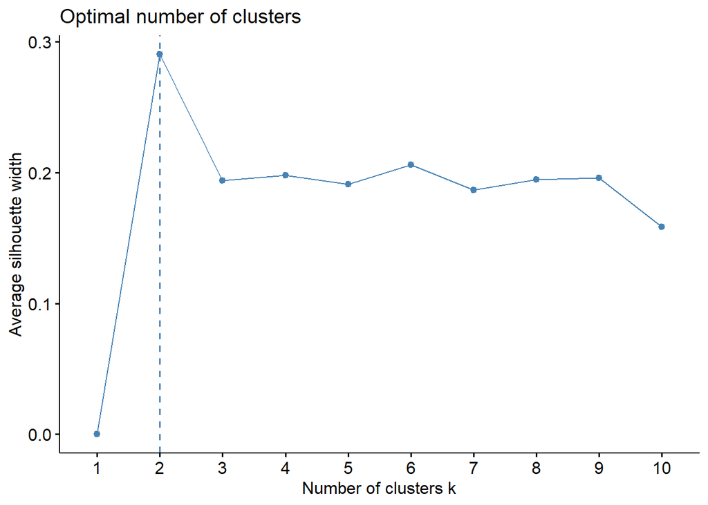

```r
#silhoutte_method
fviz_nbclust(
  data_scaled,
  kmeans,
  method = "silhouette"
)
```

Next step is k-means clustering. The “k” in k-means represents the number of clusters you want to find. The “means” refers to the average position of all the data points within a cluster (the cluster center, or centroid).

```r
#k-means_clsutering
set.seed(123)

km <- kmeans(
  data_scaled,
  centers = 4,
  nstart = 25
)

km
```

```
## K-means clustering with 4 clusters of sizes 130, 61, 119, 130
##
## Cluster means:
##         Fresh        Milk    Grocery      Frozen Detergents_Paper Delicassen
## 1  0.54020468 -0.07960844 -0.2433786  0.74628688       -0.3597453  0.4546260
## 2 -1.30955829  0.52172112  0.7026482 -1.24479279        0.7882335 -0.8960177
## 3  0.12083561  0.91292274  0.9460461 -0.07623072        0.9826730  0.5562885
## 4 -0.03633069 -1.00087459 -0.9523217 -0.09241137       -0.9096418 -0.5434049
##
## Clustering vector:
##   [1] 3 3 3 1 1 3 3 3 3 3 3 4 3 3 3 4 2 1 3 3 3 4 1 3 3 2 4 4 3 1 3 1 4 1 4 2 1
##  [38] 3 2 1 1 1 2 2 2 3 3 3 3 3 1 2 3 2 1 3 3 2 4 3 2 3 3 3 1 2 2 3 1 4 1 3 1 1
##  [75] 3 4 1 3 4 1 4 2 3 1 2 3 3 1 4 1 4 1 3 1 2 2 2 4 4 4 3 3 3 1 1 4 2 3 2 2 1
## [112] 3 1 1 4 4 4 1 1 1 1 4 4 3 1 1 1 3 2 1 1 4 4 4 4 4 3 2 1 1 1 1 4 4 4 3 4 1
## [149] 4 4 4 4 4 1 4 3 3 1 3 2 3 4 1 3 3 3 3 2 4 4 2 3 2 2 4 2 1 1 1 1 3 3 2 1 2
## [186] 4 4 2 3 2 4 4 4 2 4 1 1 3 1 4 3 3 1 4 4 3 4 2 3 3 1 3 4 3 3 3 2 1 2 4 4 2
## [223] 4 1 4 1 3 4 4 1 1 3 4 2 1 2 4 1 4 1 1 1 4 3 3 3 4 4 1 1 4 3 1 3 3 4 4 1 1
## [260] 1 4 4 4 1 2 3 3 1 3 4 4 4 2 1 4 4 1 4 1 3 4 3 1 1 1 4 4 1 4 4 4 1 1 3 1 2
## [297] 1 3 3 4 3 3 2 2 2 2 3 1 4 3 1 1 2 4 1 3 4 3 4 3 4 1 4 1 1 1 4 4 1 1 1 3 1
## [334] 3 1 3 4 1 4 1 2 3 2 2 4 2 3 3 4 3 4 3 4 2 1 4 4 2 1 2 1 4 4 4 4 3 4 4 4 4
## [371] 1 1 1 3 4 4 3 1 4 2 4 1 3 4 3 4 1 1 4 4 4 4 4 1 4 4 3 4 4 4 4 1 4 2 1 4 1
## [408] 3 3 1 1 1 2 1 1 3 3 3 2 1 2 3 1 1 3 1 3 1 1 4 3 1 4 4 3 1 1 3 1 2
##
## Within cluster sum of squares by cluster:
## [1] 310.9328 307.7432 274.5418 490.2857
##  (between_SS / total_SS =  47.5 %)
##
## Available components:
##
## [1] "cluster"      "centers"      "totss"        "withinss"     "tot.withinss"
## [6] "betweenss"    "size"         "iter"         "ifault"
```